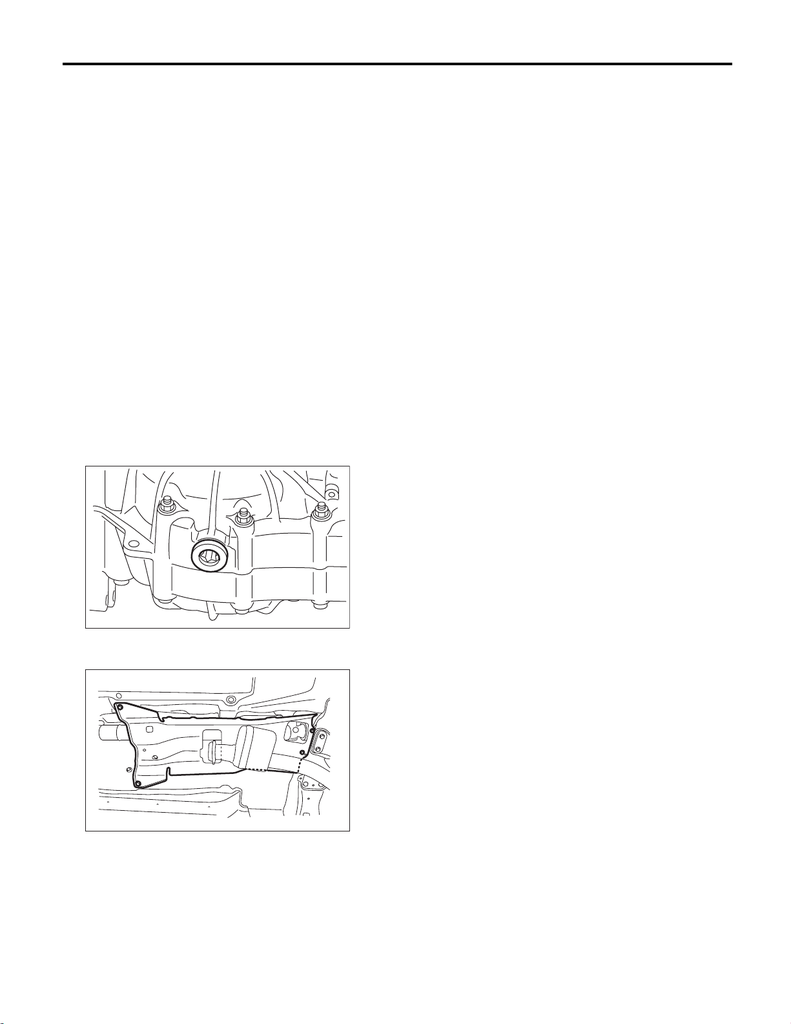

6MT(TY75)-40

Oil Seal

MANUAL TRANSMISSION AND DIFFERENTIAL

5. Oil Seal

A: INSPECTION

Check for leakage of transmission gear oil from the oil seal. If there is oil leakage, replace the oil seal with the

new part and check the propeller shaft.

B: REPLACEMENT

1) Disconnect the ground cable from battery. <Ref. to NT-5, BATTERY, NOTE, Note.>

2) Lift up the vehicle.

3) Clean the transmission exterior.

4) Using the TORX

®

bit T70, remove the drain plug, and drain the transmission gear oil completely.

CAUTION:

• Immediately after the vehicle has been running or after idling for a long time, the transmission gear

oil will be hot. Be careful not to receive burns.

• Be careful not to spill the transmission gear oil on the exhaust pipe, to prevent emission of smoke

or causing a fire. If gear oil is spilled, wipe it off completely.

5) Tighten the drain plug using TORX

®

bit T70.

NOTE:

Use a new gasket.

Tightening torque:

44 N·m (4.5 kgf-m, 32.5 ft-lb) (aluminum gasket, silver)

70 N·m (7.1 kgf-m, 51.6 ft-lb) (copper gasket, brown)

70 N·m (7.1 kgf-m, 51.6 ft-lb) (metal gasket, black)

6) Remove the rear exhaust pipe. <Ref. to EX(w/o STI)-50, REMOVAL, Rear Exhaust Pipe.>

7) Remove the center exhaust cover.

8) Remove the propeller shaft. <Ref. to DS-12, REMOVAL, Propeller Shaft.>

MT-01548

MT-03096

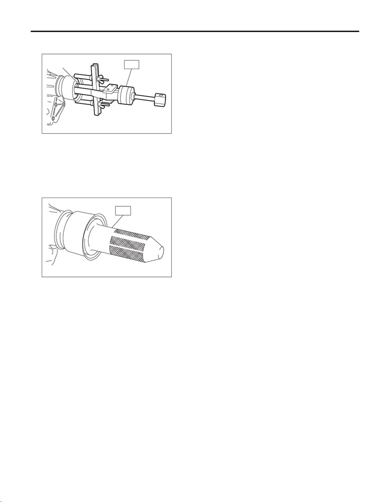

6MT(TY75)-41

Oil Seal

MANUAL TRANSMISSION AND DIFFERENTIAL

9) Using the ST, remove the oil seal.

ST 398527700 PULLER ASSY

10) Using the ST, install the oil seal.

NOTE:

• When grease is not applied to the oil seal lips, apply the transmission gear oil to the oil seal lips.

• Use a new oil seal.

ST 498057300 INSTALLER

11) Install the propeller shaft. <Ref. to DS-14, INSTALLATION, Propeller Shaft.>

12) Install the center exhaust cover.

Tightening torque:

18 N·m (1.8 kgf-m, 13.3 ft-lb)

13) Install the rear exhaust pipe. <Ref. to EX(w/o STI)-51, INSTALLATION, Rear Exhaust Pipe.>

14) Lower the vehicle.

15) Pour in transmission gear oil and check the oil level. <Ref. to 6MT(TY75)-23, Transmission Gear Oil.>

16) Connect the battery ground terminal. <Ref. to NT-5, BATTERY, NOTE, Note.>

MT-01849

(A)

ST

(A) Oil seal

MT-01850

ST